Peer Assignment 1 for Reproducible Research Course  
Author: Ajith Sasikumar  
Date: 12/18/2015

# Activity Monitoring Data Analysis

Additional Libraries used in the analyis

```r
library(dplyr)
```

First step is to download the file into the working directory, unzip it and load it into the object **activity**. The code is setup to work for https links on windows machines. setInteruse() function is used to use the Internet Explorer to download from https servers.

```r
url<-"https://d396qusza40orc.cloudfront.net/repdata%2Fdata%2Factivity.zip"
setInternet2(use = TRUE)
download.file(url,destfile = "./activity.zip")
unzip("./activity.zip")
activity<-read.csv("./activity.csv")
```

## What is the mean total number of steps taken per day?

First calculate the total number of steps taken per day.

```r
activityNoMissing<-filter(activity,!is.na(steps))
by_date<-group_by(activityNoMissing,date)
totalStepsPerDay<- summarise(by_date,total=sum(steps))
```

Let us create the histogram for the steps variable

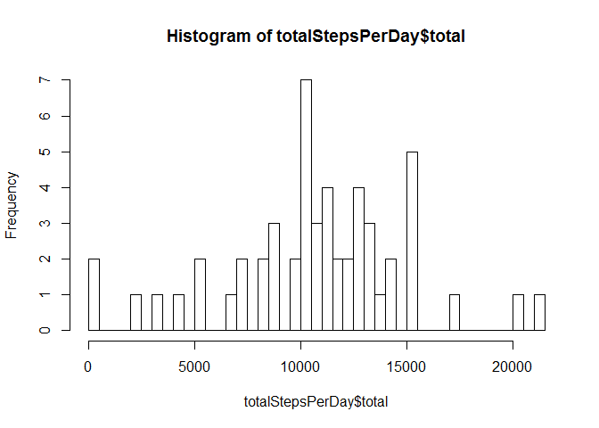

```r
hist(totalStepsPerDay$total,breaks=50)
```

Let us now summarize to get the mean and median of total number of steps in a day

```r
totalStepsNoMissingMeanMed<-c(mean=mean(totalStepsPerDay$total),median=median(totalStepsPerDay$total))
totalStepsNoMissingMeanMed
```

```
##     mean   median
## 10766.19 10765.00
```

## What is the average daily activity pattern

Using the subset of activity dataset with no missing values, we first do a group by on interval.  
Then summarise this dataset using the mean function to calcualte average.  
Finally plot the average steps per Interval across all days against the interval values.

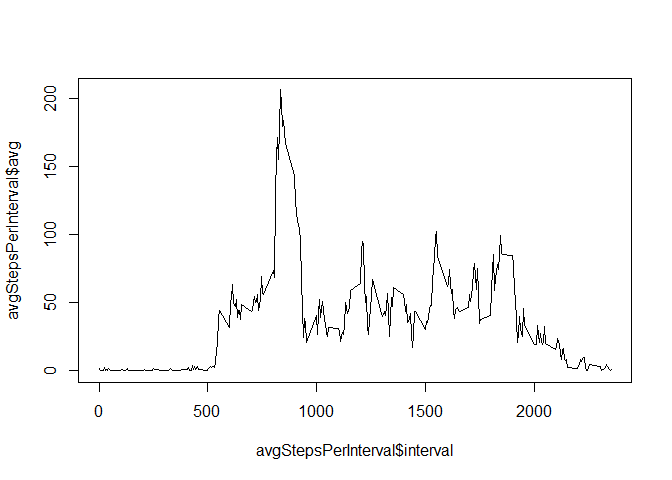

```r
by_interval <- group_by(activityNoMissing,interval)
avgStepsPerInterval<-summarise(by_interval,avg=mean(steps))
plot(avgStepsPerInterval$interval,avgStepsPerInterval$avg,type="l")
```

Which 5-minute interval, on average across all the days in the dataset, contains the maximum number of steps?

```r
avgStepsPerInterval[which.max(avgStepsPerInterval$avg),]
```

```
## Source: local data frame [1 x 2]
##
##   interval      avg
## 1      835 206.1698
```

## Imputing Mising Values

Calculate the total number of rows with missing values

```r
activityMissing<- filter(activity,is.na(steps)|is.na(date)|is.na(interval))
numberOfRowsMissingData<-dim(activityMissing)[1]
numberOfRowsMissingData
```

```
## [1] 2304
```

To impute missing values, steps listed below are done  
1.Create a duplicate of the activity dataset  
2.Check for missing values in the Steps column in Activity dataset for each row  
3. If a value is NA, then assign the value of average steps per day for that interval.

```r
activitydupe<-activity
rowcount <- dim(activitydupe)[1]
for( i in 1:rowcount)
{
  if( is.na(activitydupe[i,1]))
  {
    indexinterval<-which(avgStepsPerInterval$interval==activitydupe[i,3])

    activitydupe[i,1]<- avgStepsPerInterval[indexinterval,2]
  }
}
```

A histogram of the total number of steps taken per day is plotted.

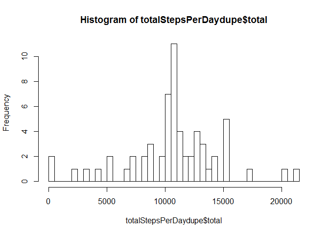

```r
by_datedupe<-group_by(activitydupe,date)
totalStepsPerDaydupe<-summarise(by_datedupe,total=sum(steps))
hist(totalStepsPerDaydupe$total,breaks=50)
```

The mean and media of the total number of steps taken per day is also calculated.

```r
totalStepsdupeMeanMed<-c(mean=mean(totalStepsPerDaydupe$total),median=median(totalStepsPerDaydupe$total))
totalStepsdupeMeanMed
```

```
##     mean   median
## 10766.19 10766.19
```

## Are there differences in activity patterns between weekdays and weekends?

1.Create a new column Weekdays with default value as Weekdays.  
2. Run through a for loop to check for each date is a Weekday or Weekend and then update the Weekdays column  
3. Change the Weekdays column to a factor

```r
rowcount <- dim(activitydupe)[1]
activitydupe$Weekdays<-"Weekdays"

for( i in 1:rowcount)
{
  if( weekdays(as.Date(activitydupe[i,2]))=="Sunday"||weekdays(as.Date(activitydupe[i,2]))=="Saturday")
  {
   activitydupe[i,4]<-"Weekend"
  }

}
activitydupe$Weekdays<-as.factor(activitydupe$Weekdays)
```

Create a Panel Plot

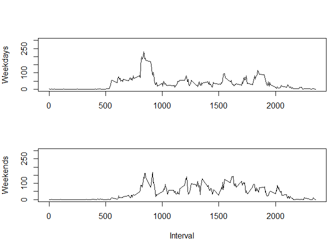

```r
par(mfrow=c(2,1),mar=c(4,4,2,1),oma=c(0,0,2,0))
activitydupeWeekdays<-activitydupe[activitydupe$Weekdays=="Weekdays",c(1,2,3)]
by_intervalWeekdays <- group_by(activitydupeWeekdays,interval)
avgStepsPerIntervalWeekdays<-summarise(by_intervalWeekdays,avg=mean(steps))
plot(avgStepsPerIntervalWeekdays$interval,avgStepsPerIntervalWeekdays$avg,type="l",xlab="",ylab="Weekdays",ylim=c(0,300))
activitydupeWeekend<-activitydupe[activitydupe$Weekdays=="Weekend",c(1,2,3)]
by_intervalWeekend <- group_by(activitydupeWeekend,interval)
avgStepsPerIntervalWeekend<-summarise(by_intervalWeekend,avg=mean(steps))
plot(avgStepsPerIntervalWeekend$interval,avgStepsPerIntervalWeekend$avg,type="l",xlab="Interval",ylab="Weekends",ylim=c(0,300))
```